# Advanced Empirical Finance: Topics and Data Science

Transaction costs and parametric portfolio policies

Stefan Voigt

University of Copenhagen and Danish Finance Institute (DFI)

Spring 2027

## From Monday, every trade costs

- **Trading game:** from 1 March, every trade costs 10 bps (0.1 %) of its value
- Turnover per month of the strategies of lecture 4: plug-in minimum variance 61%, Ledoit-Wolf 23%, no short sales 16%, 1/N 4%

**Today:** how trading costs change the optimal portfolio, and a portfolio rule with a handful of parameters for thousands of stocks

# Transaction costs

## What trading costs

- **Proportional costs:** spreads, fees, commissions. A trade of $|\Delta\omega_i|$ costs $c\,|\Delta\omega_i|$ of wealth, e.g. $c$ = 10 bps in the trading game
- **Price impact:** large trades move the price; the cost grows faster than the trade. A quadratic cost $\frac{\beta}{2}\Delta\omega_i^2$ is a common approximation
- **Weights drift:** even without trading, prices move the weights. Before rebalancing, the portfolio holds

$$\omega_{t^+} = \frac{\omega_t \circ (1 + r_t)}{\iota'\big(\omega_t \circ (1 + r_t)\big)}$$

so the trade is $\omega_{t+1} - \omega_{t^+}$, and the turnover is $\sum_i |\omega_{i,t+1} - \omega_{i,t^+}|$

## Lecture 4’s strategies after costs

| Strategy | Sharpe ratio, no costs | Sharpe ratio, 10 bps | Sharpe ratio, 50 bps | Turnover per month |
| --- | --- | --- | --- | --- |
| Buy and hold | 1.05 | 1.05 | 1.05 | 0% |
| 1/N | 0.96 | 0.95 | 0.94 | 4% |
| Minimum variance, no short sales | 0.86 | 0.85 | 0.79 | 16% |
| Ledoit-Wolf minimum variance | 0.90 | 0.87 | 0.79 | 23% |
| Plug-in minimum variance | 0.78 | 0.74 | 0.55 | 61% |

- Dow Jones stocks, 60-month windows, 2005–2025, excess returns net of proportional costs on the turnover
- The more a strategy trades, the more costs take away: 1/N gains on the minimum-variance portfolios
- **Buy and hold** starts with 1/N in February 2005 and never trades. It lets the winners grow, and today’s Dow Jones stocks are the winners we know today: look-ahead bias in the choice of stocks (lecture 3)

## Whiteboard: quadratic transaction costs

Mean-variance with a cost for moving away from the current weights (Hautsch & Voigt, 2019):
$$\omega_{t+1} = \arg\max_{\iota'\omega = 1} \ \omega'\mu - \frac{\beta}{2}(\omega - \omega_{t^+})'(\omega - \omega_{t^+}) - \frac{\gamma}{2}\omega'\Sigma\omega$$

- The same problem as Markowitz, with

$$\Sigma^* = \Sigma + \frac{\beta}{\gamma}I \qquad \mu^* = \mu + \beta\,\omega_{t^+}$$

- **Costs act as shrinkage:** $\Sigma^*$ shrinks the covariance matrix toward the identity, as in lecture 4, and $\mu^*$ pulls the weights toward the current portfolio
- $\beta = 0$: Markowitz. $\beta \to \infty$: no trading, $\omega_{t+1} = \omega_{t^+}$

## Costs change the path, not the destination

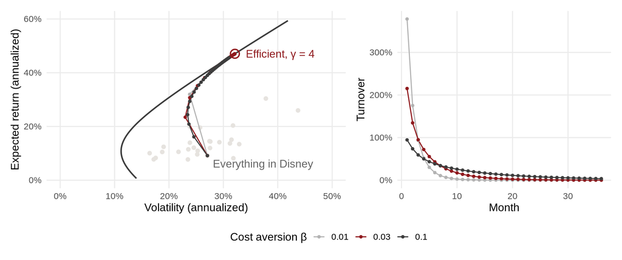

- Known $\mu$ and $\Sigma$ (lecture 2), $\gamma = 4$, no drift. Each month: the cost-aware weights given last month’s portfolio
- Without costs, one trade of 748% of wealth (large long and short positions) gets there. With costs, the trade is spread over months: the larger $\beta$, the slower
- Every path ends at the efficient portfolio: first close to the frontier, then along it

## Proportional costs: the no-trade zone

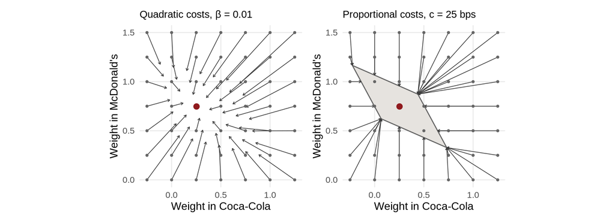

- Coca-Cola, McDonald’s and cash for one month, $\gamma = 4$. Red: $\omega^*$, the portfolio without costs; arrows: the trades
- **Quadratic costs:** every portfolio moves part of the way to $\omega^*$
- **Proportional costs** $c\,\iota'|\omega - \omega_{t^+}|$, no closed form: inside the **no-trade zone** $|\gamma\Sigma(\omega - \omega^*)| \le c$ no trade is worth its cost; outside, trade to its edge

## Cost-aware weights in code

- R
- Python

```r
# Hautsch & Voigt (2019): Markowitz with Sigma + beta / gamma * I and
# mu = beta * w_plus; mu = 0 otherwise, so no expected returns are estimated
cost_aware_weights <- function(sigma, w_plus, beta) {
  n <- ncol(sigma)
  sigma_star <- sigma + beta / gamma * diag(n)
  mu_star <- beta * w_plus
  sigma_inv <- solve(sigma_star)
  w_mvp <- rowSums(sigma_inv) / sum(sigma_inv)
  a <- sigma_inv - tcrossprod(rowSums(sigma_inv)) / sum(sigma_inv)
  as.vector(w_mvp + a %*% mu_star / gamma)
}
```

```python
# Hautsch & Voigt (2019): Markowitz with Sigma + beta / gamma * I and
# mu = beta * w_plus; mu = 0 otherwise, so no expected returns are estimated
def cost_aware_weights(sigma, w_plus, beta):
    n = len(w_plus)
    sigma_star = sigma + beta / gamma * np.eye(n)
    mu_star = beta * w_plus
    sigma_inv = np.linalg.inv(sigma_star)
    ones = np.ones(n)
    w_mvp = sigma_inv @ ones / (ones @ sigma_inv @ ones)
    a = sigma_inv - np.outer(sigma_inv @ ones, ones @ sigma_inv) / (ones @ sigma_inv @ ones)
    return w_mvp + a @ mu_star / gamma
```

We choose the weights with the quadratic penalty and pay proportional costs on the trades

## Cost-aware weights without short sales

The same objective as a quadratic program: minimize $\frac{1}{2}\omega'(\gamma\Sigma + \beta I)\,\omega - \beta\,\omega_{t^+}'\omega$ subject to $\iota'\omega = 1$ and $\omega \ge 0$

- R
- Python

```r
cost_aware_weights_no_short <- function(sigma, w_plus, beta) {
  n <- ncol(sigma)
  solve.QP(
    Dmat = gamma * sigma + beta * diag(n), dvec = beta * w_plus,
    Amat = cbind(1, diag(n)), bvec = c(1, rep(0, n)), meq = 1
  )$solution
}
```

```python
def cost_aware_weights_no_short(sigma, w_plus, beta):
    n = len(w_plus)
    d = gamma * sigma + beta * np.eye(n)
    return minimize(
        lambda w: w @ d @ w / 2 - beta * w_plus @ w, x0=w_plus, jac=lambda w: d @ w - beta * w_plus,
        bounds=[(0, 1)] * n, method="SLSQP", options={"ftol": 1e-12},
        constraints={"type": "eq", "fun": lambda w: w.sum() - 1},
    ).x
```

- $\beta = 0$: lecture 4’s minimum variance with no short sales. $\beta \to \infty$: the weights stay at $\omega_{t^+}$, buy and hold

## The Dow Jones with costs

- R
- Python

```r
backtest_costs <- expand_grid(short_sales = c(TRUE, FALSE), beta = betas) |>
  pmap(\(short_sales, beta) {
    choose_weights <- if (short_sales) cost_aware_weights else cost_aware_weights_no_short
    w <- rep(1 / n_stocks, n_stocks)
    results <- vector("list", length(months))
    for (k in seq_along(months)) {
      t <- months[k]
      sigma <- cov(excess_matrix[(t - window_length):(t - 1), ])
      drift <- w * (1 + returns_matrix[t - 1, ])
      w_plus <- drift / sum(drift)
      w <- choose_weights(sigma, w_plus, beta)
      results[[k]] <- tibble(
        short_sales = short_sales, beta = beta, date = dates[t],
        ret_excess = sum(w * excess_matrix[t, ]), turnover = sum(abs(w - w_plus))
      )
    }
    bind_rows(results)
  }) |>
  bind_rows()
```

```python
records = []
for short_sales in [True, False]:
    choose_weights = cost_aware_weights if short_sales else cost_aware_weights_no_short
    for beta in betas:
        w = np.full(n_stocks, 1 / n_stocks)
        for t in range(window_length, n_months):
            sigma = np.cov(excess_matrix[t - window_length:t], rowvar=False)
            drift = w * (1 + returns_matrix[t - 1])
            w_plus = drift / drift.sum()
            w = choose_weights(sigma, w_plus, beta)
            records.append({"short_sales": short_sales, "beta": beta, "date": dates[t],
                            "ret_excess": w @ excess_matrix[t], "turnover": np.abs(w - w_plus).sum()})
backtest_costs = pl.DataFrame(records)
```

`returns_matrix` holds the returns, `excess_matrix` the excess returns, one column per stock; `betas` is a grid from 0 to 1000 (as floats)

## How much cost aversion?

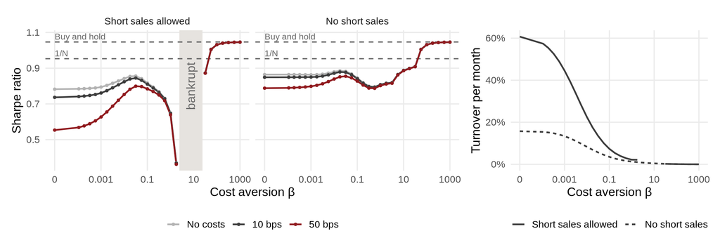

- **Small $\beta$:** Sharpe ratio after 10 bps from 0.74 to 0.84 at $\beta \approx$ 0.03, turnover from 61% to 13%
- **Large $\beta$:** no trading, buy and hold (1.05), which wins here only through the choice of stocks
- **Short sales allowed,** $\beta$ from 3 to 18: too slow to close a short in NVIDIA while its price rises, bankrupt in 2024–2025

# Parametric portfolio policies

## Many stocks, few parameters

- The US stock market has thousands of stocks. Estimating $\mu$ and $\Sigma$ for all of them is hopeless, even with shrinkage
- What we know about a stock is in its **characteristics**: size, value, momentum, profitability, …
- Brandt, Santa-Clara & Valkanov (2009): model the **weights** directly as a function of the characteristics, with one coefficient per characteristic for all stocks and all months

## Which characteristics would you use?

In the lecture, you name the stock characteristics you would use to tilt a portfolio away from the market, and an AI groups them into a word cloud

Brandt, Santa-Clara & Valkanov (2009) use **size**, **book-to-market** and **momentum**. We use size and momentum from CRSP; book-to-market needs accounting data

## Whiteboard: parametric portfolio policies

Tilt a benchmark $\bar\omega_{i,t}$ (e.g. value weights) with standardized characteristics $\hat x_{i,t}$:
$$\omega_{i,t} = \bar\omega_{i,t} + \frac{1}{N_t}\theta'\hat x_{i,t}
\qquad \text{and choose} \qquad
\max_\theta \ \frac{1}{T}\sum_{t} u\big(r_{p,t+1}(\theta)\big)$$

- $\theta$ is the same for every stock and month: **two parameters** for two characteristics, whether there are 30 or 5,000 stocks
- The characteristics have mean zero across stocks every month, so the tilts sum to zero and the weights to one
- No $\mu$ or $\Sigma$: the policy maximizes the average utility of its own returns, so skewness and fat tails count, too
- Costs and constraints (e.g. no short sales) can go into the objective

## Characteristics from CRSP

- R
- Python

```r
crsp_monthly <- read_parquet(
  "data/crsp_monthly.parquet",
  col_select = c("permno", "date", "ret_excess", "mktcap", "mktcap_lag")
)
crsp_lags <- crsp_monthly |>
  transmute(permno, date = date %m+% months(13), mktcap_13 = mktcap)

policy_data <- crsp_monthly |>
  inner_join(crsp_lags, join_by(permno, date)) |>
  filter(date >= policy_start) |>
  transmute(
    permno, date, ret_excess, mktcap_lag,
    momentum = mktcap_lag / mktcap_13,
    size = log(mktcap_lag)
  ) |>
  drop_na()
```

```python
crsp_monthly = pl.read_parquet(
    "data/crsp_monthly.parquet",
    columns=["permno", "date", "ret_excess", "mktcap", "mktcap_lag"],
)
crsp_lags = crsp_monthly.select(
    "permno", pl.col("date").dt.offset_by("13mo"), mktcap_13=pl.col("mktcap")
)

policy_data = (
    crsp_monthly.join(crsp_lags, on=["permno", "date"])
    .filter(pl.col("date") >= date(1980, 1, 1))
    .select(
        "permno", "date", "ret_excess", "mktcap_lag",
        momentum=pl.col("mktcap_lag") / pl.col("mktcap_13"),
        size=pl.col("mktcap_lag").log(),
    )
    .drop_nulls()
)
```

Momentum: the change in market value from month $t-13$ to $t-1$, as in the Tidy Finance chapter [Parametric portfolio policies](https://www.tidy-finance.org/chapters/parametric-portfolio-policies.html); size: the log market value at $t-1$

## Standardized characteristics and benchmark weights

- R
- Python

```r
policy_data <- policy_data |>
  mutate(
    across(c(momentum, size), \(x) (x - mean(x)) / sd(x)),
    weight_benchmark = mktcap_lag / sum(mktcap_lag),
    n = n(),
    .by = date
  )
```

```python
policy_data = policy_data.with_columns(
    *[((pl.col(c) - pl.col(c).mean().over("date")) / pl.col(c).std().over("date")).alias(c)
      for c in ["momentum", "size"]],
    weight_benchmark=pl.col("mktcap_lag") / pl.col("mktcap_lag").sum().over("date"),
    n=pl.len().over("date"),
)
```

Every month, the characteristics have mean zero and standard deviation one across stocks; the benchmark is the value-weighted market

## Estimating $\theta$

- R
- Python

```r
policy_returns <- function(theta, data) {
  data |>
    mutate(weight = weight_benchmark + (theta[1] * momentum + theta[2] * size) / n) |>
    summarize(ret = sum(weight * ret_excess), .by = date)
}

average_utility <- function(theta, data) {
  r <- policy_returns(theta, data)$ret
  mean((1 + r)^(1 - gamma_policy) / (1 - gamma_policy))
}

in_sample <- policy_data |> filter(date < policy_split)
fit <- optim(
  c(0, 0), \(theta) -average_utility(theta, in_sample),
  method = "Nelder-Mead", control = list(reltol = 1e-12, maxit = 1000)
)
theta <- fit$par
```

```python
def policy_returns(theta, data):
    return (
        data.with_columns(
            weight=pl.col("weight_benchmark")
            + (theta[0] * pl.col("momentum") + theta[1] * pl.col("size")) / pl.col("n")
        )
        .group_by("date")
        .agg(ret=(pl.col("weight") * pl.col("ret_excess")).sum())
        .sort("date")
    )

def average_utility(theta, data):
    r = policy_returns(theta, data)["ret"].to_numpy()
    return np.mean((1 + r) ** (1 - gamma_policy) / (1 - gamma_policy))

in_sample = policy_data.filter(pl.col("date") < date(2010, 1, 1))
fit = minimize(lambda theta: -average_utility(theta, in_sample), x0=[0, 0],
               method="Nelder-Mead", options={"xatol": 1e-8, "fatol": 1e-14})
theta = fit.x
```

CRRA utility with $\gamma$ = 5, estimated on 1980–2009: $\hat\theta_\text{momentum}$ = 0.48, $\hat\theta_\text{size}$ = -1.90. The policy tilts toward past winners and toward small stocks

## In sample and out of sample

| Period | Portfolio | Excess return | Volatility | Sharpe ratio |
| --- | --- | --- | --- | --- |
| In sample, 1980–2009 | Value-weighted market | 6.5% | 15.8% | 0.41 |
| In sample, 1980–2009 | Parametric policy | 12.9% | 19.6% | 0.66 |
| Out of sample, 2010–2025 | Value-weighted market | 13.1% | 14.9% | 0.88 |
| Out of sample, 2010–2025 | Parametric policy | 9.0% | 20.2% | 0.45 |

- In sample, the policy beats the market (Sharpe ratio 0.66 against 0.41); out of sample it falls behind (0.45 against 0.88): after 2009, large stocks led
- Few parameters reduce estimation error, but they cannot protect against a world that changes. Out-of-sample evaluation again

## Portfolio choice in five lectures

- **Mean-variance** gives the optimal portfolio, if we knew $\mu$ and $\Sigma$
- **Estimation error** makes plug-in portfolios fail out of sample; 1/N is hard to beat
- **Shrinkage, constraints and priors** trade a little bias for much less variance
- **Transaction costs** shrink, too, and make trading less often optimal
- **Parametric policies** replace $N$ means and $N(N+1)/2$ covariances with a few coefficients

Assignment 1 on portfolio choice starts today